# Evaluación Interactiva de Matemáticas ICFES

La gráfica y la tabla muestran parte de la información que recibe la familia Rodríguez en su factura telefónica del mes de enero.

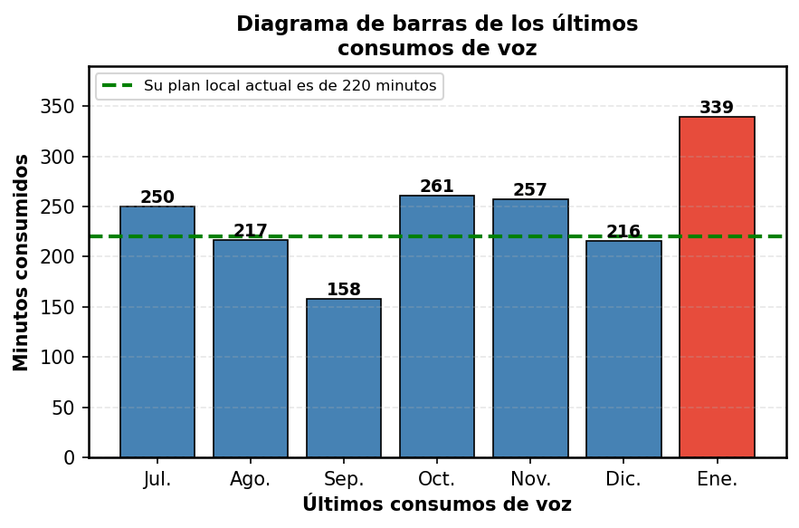

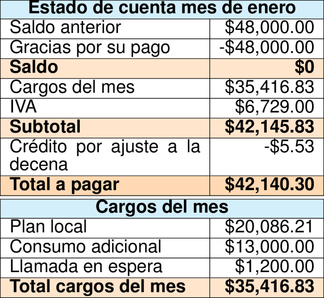

El tiempo adicional consumido por la familia Rodríguez en enero fue:

5 horas y 54 minutos.2 horas y 43 minutos.1 hora y 59 minutos.1 hora y 37 minutos.

Para resolver este problema, debemos:

1. **Identificar el plan actual**: Según la gráfica, el plan local actual es de **220 minutos**.
2. **Identificar el consumo de enero**: En el gráfico de barras, el consumo de enero (la última barra) es de **339 minutos**.
3. **Calcular el tiempo adicional**:
   $$\text{Tiempo adicional} = \text{Consumo enero} -
   \text{Plan actual}$$
   $$\text{Tiempo
   adicional} = 339 - 220 = 119 \text{ minutos}$$
4. **Convertir a horas y minutos**:
   - Horas: $\lfloor 119 \div 60 \rfloor = 1$ hora(s)
   - Minutos restantes: $119 \mod 60 = 59$ minutos

**Respuesta correcta**: 1 hora y 59 minutos.

- Falso
- Falso
- Verdadero
- Falso

La gráfica y la tabla muestran parte de la información que recibe la familia Pérez en su factura telefónica del mes de enero.

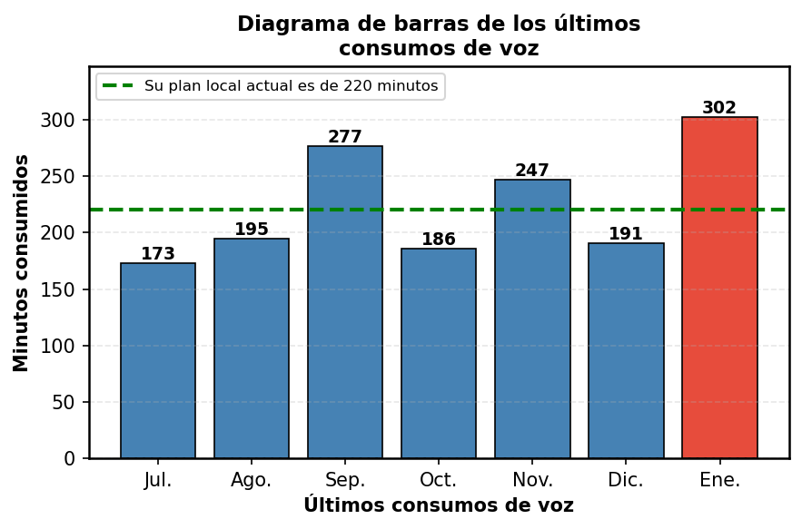

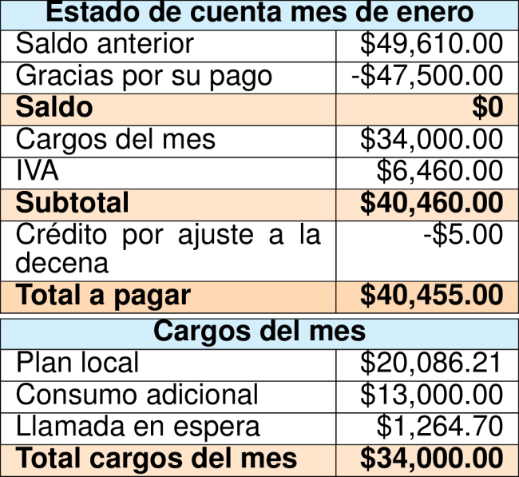

El tiempo adicional consumido por la familia Pérez en enero fue:

2 horas y 11 minutos.5 horas y 7 minutos.0 horas y 53 minutos.1 hora y 22 minutos.

Para resolver este problema, debemos:

1. **Identificar el plan actual**: Según la gráfica, el plan local actual es de **220 minutos**.
2. **Identificar el consumo de enero**: En el gráfico de barras, el consumo de enero (la última barra) es de **302 minutos**.
3. **Calcular el tiempo adicional**:
   $$\text{Tiempo adicional} = \text{Consumo enero} -
   \text{Plan actual}$$
   $$\text{Tiempo
   adicional} = 302 - 220 = 82 \text{ minutos}$$
4. **Convertir a horas y minutos**:
   - Horas: $\lfloor 82 \div 60 \rfloor = 1$ hora(s)
   - Minutos restantes: $82 \mod 60 = 22$ minutos

**Respuesta correcta**: 1 hora y 22 minutos.

- Falso
- Falso
- Falso
- Verdadero

La gráfica y la tabla muestran parte de la información que recibe la familia Martínez en su factura telefónica del mes de enero.

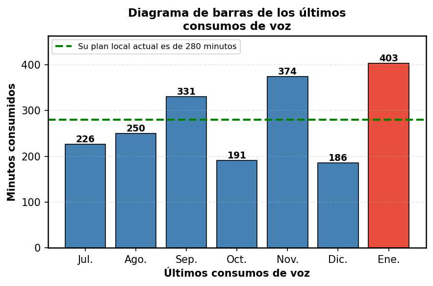

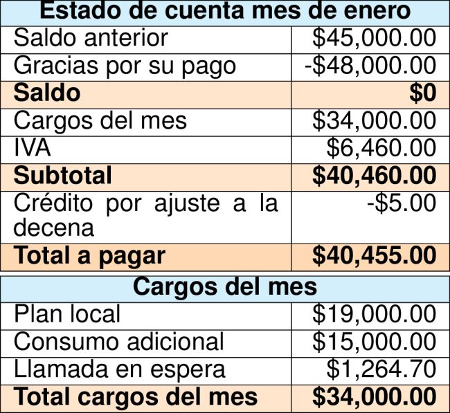

El tiempo adicional consumido por la familia Martínez en enero fue:

2 horas y 46 minutos.1 hora y 33 minutos.2 horas y 3 minutos.5 horas y 55 minutos.

Para resolver este problema, debemos:

1. **Identificar el plan actual**: Según la gráfica, el plan local actual es de **280 minutos**.
2. **Identificar el consumo de enero**: En el gráfico de barras, el consumo de enero (la última barra) es de **403 minutos**.
3. **Calcular el tiempo adicional**:
   $$\text{Tiempo adicional} = \text{Consumo enero} -
   \text{Plan actual}$$
   $$\text{Tiempo
   adicional} = 403 - 280 = 123 \text{ minutos}$$
4. **Convertir a horas y minutos**:
   - Horas: $\lfloor 123 \div 60 \rfloor = 2$ hora(s)
   - Minutos restantes: $123 \mod 60 = 3$ minutos

**Respuesta correcta**: 2 horas y 3 minutos.

- Falso
- Falso
- Verdadero
- Falso